# Electricity Power Plants in the United States

Yingfei Jiang

1/31/2020

### Task 1. Data wrangling & visualization

This project will explore the electricity generation plants in the United States and their air pollutants and greenhouse gas (GHG) emissions. There are three parts in this porject.  
Part one explores the average electricity GHG emission factor on a state level and how they are affected by the electricty mix in different state (renewable-to-total and natural-gas-to-fossil-fuel). In carbon accounting, this is called **scope II emission**.  
Part two explores the generation plants in ten most populated states, and their total $NO_x$, $SO_2$, and GHG emission in 2018.  
Part three explores the electricity generation and emissions for California counties in 2018.

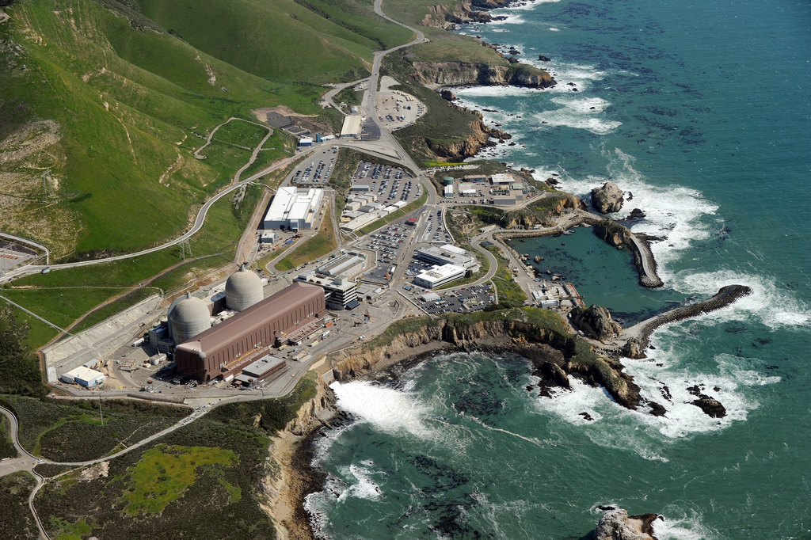

**Figure 1. The Diablo Canyon Nuclear Power Plant.** Located in San Luis Obispo county, the Diablo Canyon nuclear power plant is the last operating nuclear power plant in California. (Source: The New York Times, 2016)

```r
#Read in data sets.

raw_df <- read_excel("egrid2018_data.xlsx", skip = 1, sheet = "PLNT18")
raw_df_st <- read_excel("egrid2018_data.xlsx", skip = 1, sheet = "ST18")
```

```r
clean_df <- raw_df %>%
  clean_names() %>%
  select(pstatabb, cntyname, fipsst, fipscnty, plprmfl, plfuelct, coalflag, namepcap, plnoxrta, plso2rta, plco2rta, plch4rta, pln2orta, plc2erta, plso2an, plnoxan, plco2eqa, plngenan) #Selecting the cateogries of interest
```

```r
clean_st_df <- raw_df_st %>%
  clean_names() %>%
  select(pstatabb, stnoxrta, stso2rta, namepcap, stgenatn, stc2erta, sttrpr, stgspr, sttnpr, stngenan) %>%
  mutate(gas_ratio = stgspr/sttnpr) #Calculating the percentage of gas-generated electricity among all fossil fuel-generated electricity.
```

#### **Part One.** The average electricity GHG emission factor on a state level.

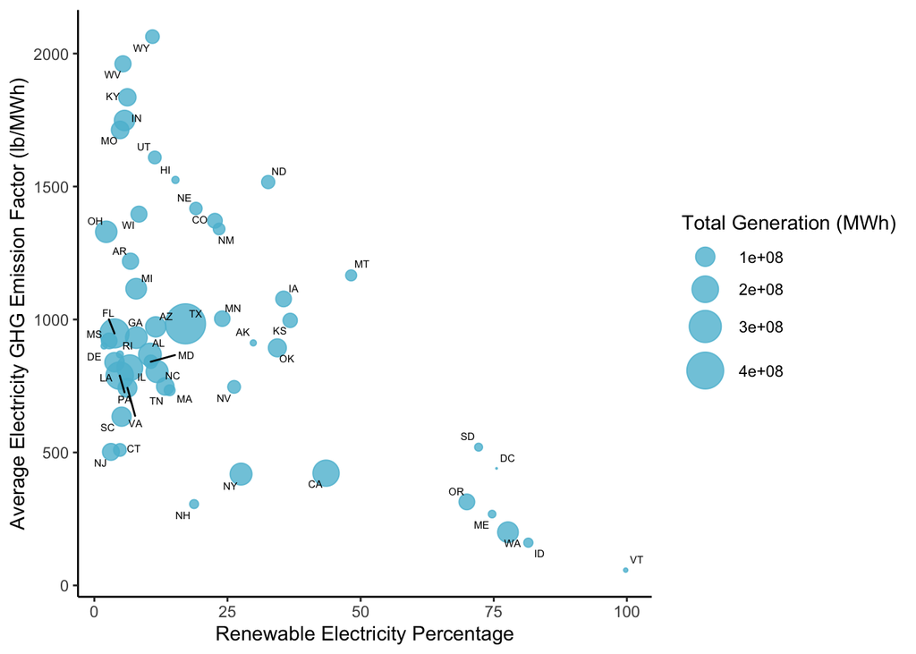

```r
state_bubble <- ggplot(clean_st_df, aes(x = sttrpr*100, y = stc2erta, size = stngenan)) +
  geom_point(alpha = 0.8, color = "#5BBCD6")+
  scale_size(range = c(.1, 10), name="Total Generation (MWh)")+
  xlab("Renewable Electricity Percentage")+
  ylab("Average Electricity GHG Emission Factor (lb/MWh)")+
  geom_text_repel(aes(label = pstatabb), size = 2)+
  theme_classic()


state_bubble
```

**Figure 2. The Relationship between Average Electricity GHG Emission Factor and Renewable Generation Percentage on a State Level.** Each bubble stands for a state. The size of the bubble indicates the total electricity generation in the state. The data for generation and GHG emission are from the year of 2018. (Source: eGrid, 2018)

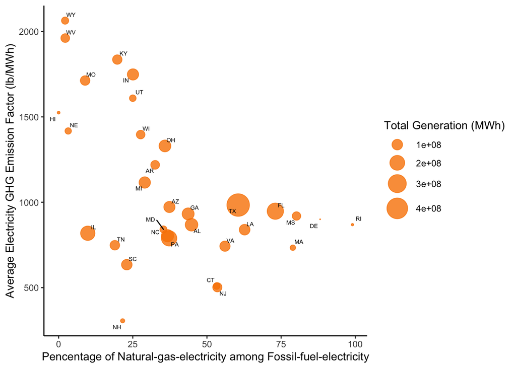

```r
clean_st_fossil <- clean_st_df %>%
  filter(sttnpr > 0.80)

state_fs_bubble <- ggplot(clean_st_fossil, aes(x = gas_ratio*100, y = stc2erta, size = stngenan)) +
  geom_point(alpha = 0.8, color = "#F98400")+
  scale_size(range = c(.1, 10), name="Total Generation (MWh)")+
  xlab("Pencentage of Natural-gas-electricity among Fossil-fuel-electricity")+
  ylab("Average Electricity GHG Emission Factor (lb/MWh)")+
  geom_text_repel(aes(label = pstatabb), size = 2)+
  theme_classic()

state_fs_bubble
```

**Figure 3. The Relationship between Average Electricity GHG Emission Factor and the Pencentage of Natural-gas-electricity among Fossil-fuel-electricity for States with More than 80% Non-renewable Electricity.** Each bubble stands for a state. The size of the bubble indicates the total electricity generation in the state. The data for generation and GHG emission are from the year of 2018. (Source: eGrid, 2018)

#### **Part Two.** The generation plants in ten most populated states.

```r
gas_df <- clean_df %>%
  filter (plfuelct %in% c("GAS", "OIL", "COAL"))%>% # Selecting all fossil fuels
  group_by(pstatabb) %>%
  select(-coalflag) %>%
  drop_na() %>%
  filter(pstatabb %in% c("CA", "TX", "FL", "NY", "PA", "IL", "OH", "GA", "NC", "MI"))# Selecting the top ten populated states
```

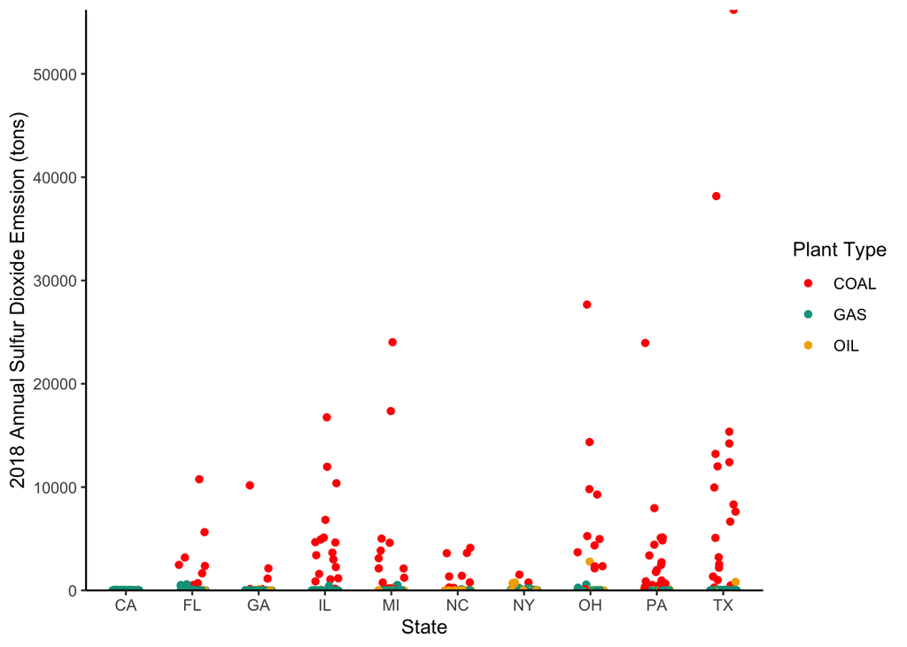

```r
gasvis2 <- ggplot(gas_df, aes(x = pstatabb, y = plso2an))+
  geom_jitter(width = 0.20, aes(color = plfuelct))+
  theme_classic()+
  scale_y_continuous(expand = c(0, 0))+
  scale_color_manual(values=wes_palette(n=3, name="Darjeeling1"))+
  xlab("State")+
  ylab("2018 Annual Sulfur Dioxide Emssion (tons)")+
  labs(color = "Plant Type")

gasvis2
```

**Figure 4. Total Annual $SO_2$ Emission on a Power Plant Level for Ten Most Populated States.** Each point stands for a power plant. The color of the point indicates the type of the power plant. The data for generation and GHG emission are from the year of 2018. (Source: eGrid, 2018)

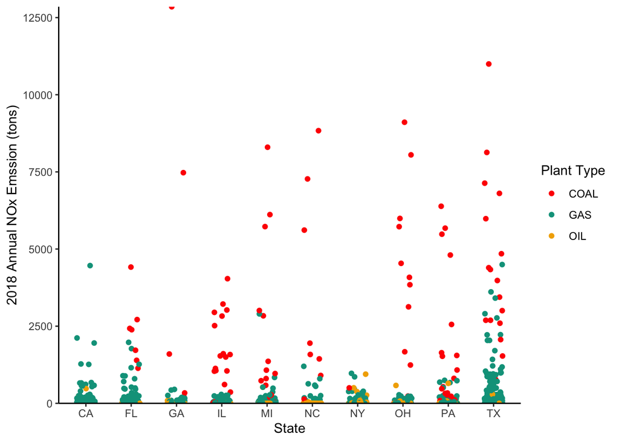

```r
gasvis4 <- ggplot(gas_df, aes(x = pstatabb))+
  geom_jitter(width = 0.20, aes(y = plnoxan,color = plfuelct))+
  theme_classic()+
  scale_y_continuous(expand = c(0, 0))+
  scale_color_manual(values=wes_palette(n=3, name="Darjeeling1"))+
  xlab("State")+
  ylab("2018 Annual NOx Emssion (tons)")+
  labs(color = "Plant Type")

gasvis4
```

**Figure 5. Total Annual $NO_x$ Emission on a Power Plant Level for Ten Most Populated States.** Each point stands for a power plant. The color of the point indicates the type of the power plant. The data for generation and GHG emission are from the year of 2018. (Source: eGrid, 2018)

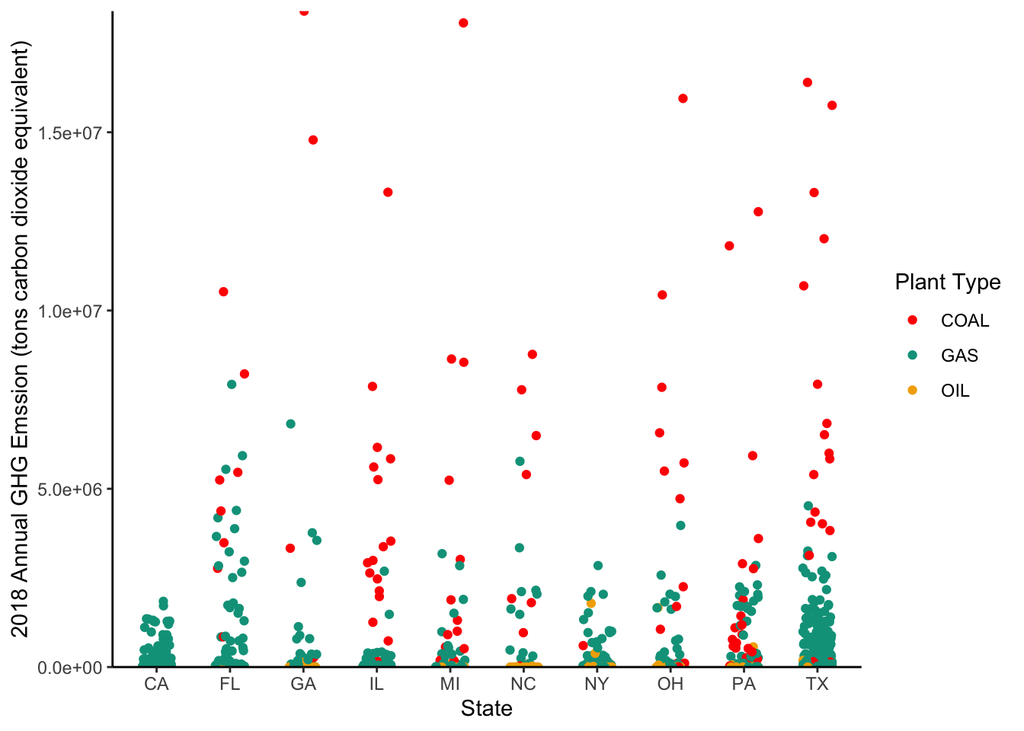

```r
gasvis5 <- ggplot(gas_df, aes(x = pstatabb))+
  geom_jitter(width = 0.20, aes(y = plco2eqa,color = plfuelct))+
  theme_classic()+
  scale_y_continuous(expand = c(0, 0))+
  scale_color_manual(values=wes_palette(n=3, name="Darjeeling1"))+
  xlab("State")+
  ylab("2018 Annual GHG Emssion (tons carbon dioxide equivalent)")+
  labs(color = "Plant Type")

gasvis5
```

**Figure 6. Total Annual GHG Emission on a Power Plant Level for Ten Most Populated States.** Each point stands for a power plant. The color of the point indicates the type of the power plant. The data for generation and GHG emission are from the year of 2018. (Source: eGrid, 2018)

#### **Part Three.** Electricity generation and emissions for California counties

```r
ca_df <- clean_df %>%
  filter(pstatabb == "CA") %>%
  select(-coalflag) %>%
  mutate(cntyname = str_to_title(cntyname)) %>%
  group_by(cntyname) %>%
  mutate(plso2an = replace_na(plso2an, 0)) %>%
  mutate(plnoxan = replace_na(plnoxan, 0)) %>%
  filter (is.na (plngenan) == FALSE) %>%
  summarise(nox_total = sum(plnoxan),
            so2_total = sum(plso2an),
            gen_total = sum(plngenan)) %>%
  mutate(nox_rt = scales::number(nox_total*2000/gen_total, accuracy = 0.001),
         so2_rt = scales::number(so2_total*2000/gen_total, accuracy = 0.001)) %>%
  mutate(nox_rt = cell_spec(nox_rt, "html", bold = T, color = ifelse(nox_rt > 0.377, "#F2AD00", "#00A08A"), background = "#d7eff5"),
         so2_rt = cell_spec(so2_rt, "html", bold = T, color = ifelse(so2_rt > 0.036, "#F2AD00", "#00A08A"), background = "#d7eff5"))


title <- c("County", "Total NOx Emission (tons)", "Total SO2 Emission (tons)", "Total Net Generation (MWh)", "NOx Emission Rate (lb/MWh)", "SO2 Emission Rate(lb/MWh)")

colnames(ca_df) <- title
```

```r
my_tbl <- ca_df %>%
  kable(escape=F, align = "r") %>%
  kable_styling(bootstrap_options = c("striped", "hover", "condensed")) %>%
  column_spec(1, bold = T, color = "white", background = "#046C9A") %>%
  row_spec(0, bold = T, color = "white", background = "#F98400")%>%
  scroll_box(width = "100%", height = "300px")
```

**Table 1. 2018 Electricity Generation and Emission for California Counties.** Total $NO_x$ And $SO_2$ emission, total net generation amount, and corresponding emission factor are shown in the table. If the emission factor for a pollutant type is higher than California average, it is marked as yellow. Otherwise, it is marked as green. (Source: eGrid, 2018)

| County | Total NOx Emission (tons) | Total SO2 Emission (tons) | Total Net Generation (MWh) | NOx Emission Rate (lb/MWh) | SO2 Emission Rate(lb/MWh) |
| --- | --- | --- | --- | --- | --- |
| Alameda | 723.060 | 23.439 | 2033905.00 | 0.711 | 0.023 |
| Amador | 0.000 | 0.000 | 738753.00 | 0.000 | 0.000 |
| Butte | 8.811 | 2.135 | 2353681.00 | 0.007 | 0.002 |
| Calaveras | 0.000 | 0.000 | 493930.00 | 0.000 | 0.000 |
| Colusa | 163.039 | 34.964 | 3152517.00 | 0.103 | 0.022 |
| Contra Costa | 3419.368 | 58.228 | 14286071.00 | 0.479 | 0.008 |
| El Dorado | 167.884 | 0.200 | 1360204.00 | 0.247 | 0.000 |
| Fresno | 256.030 | 39.102 | 6871723.00 | 0.075 | 0.011 |
| Glenn | 0.000 | 0.000 | 7791.00 | 0.000 | 0.000 |
| Humboldt | 4732.149 | 49.976 | 536932.00 | 17.627 | 0.186 |
| Imperial | 54.158 | 1413.840 | 8388389.07 | 0.013 | 0.337 |
| Inyo | 0.000 | 549.855 | 1373519.00 | 0.000 | 0.801 |
| Kern | 6663.567 | 122.718 | 32066102.00 | 0.416 | 0.008 |
| Kings | 268.177 | 0.526 | 1197595.00 | 0.448 | 0.001 |
| Lake | 1.306 | 0.270 | 943400.00 | 0.003 | 0.001 |
| Lassen | 423.338 | 33.600 | 274015.00 | 3.090 | 0.245 |
| Los Angeles | 8013.808 | 497.241 | 22910992.61 | 0.700 | 0.043 |
| Madera | 283.825 | 0.490 | 890244.99 | 0.638 | 0.001 |
| Marin | 0.000 | 5.402 | 29920.00 | 0.000 | 0.361 |
| Mariposa | 0.000 | 0.000 | 269655.00 | 0.000 | 0.000 |
| Mendocino | 0.000 | 0.000 | 19041.00 | 0.000 | 0.000 |
| Merced | 28.840 | 0.158 | 251373.00 | 0.229 | 0.001 |
| Mono | 0.000 | 0.000 | 400981.00 | 0.000 | 0.000 |
| Monterey | 257.263 | 16.413 | 4975840.84 | 0.103 | 0.007 |
| Napa | 0.000 | 0.000 | 1566.00 | 0.000 | 0.000 |
| Nevada | 0.000 | 0.000 | 273679.00 | 0.000 | 0.000 |
| Orange | 1995.386 | 81.375 | 1442024.21 | 2.767 | 0.113 |
| Placer | 181.772 | 46.269 | 1976944.00 | 0.184 | 0.047 |
| Plumas | 120.342 | 20.313 | 1342157.00 | 0.179 | 0.030 |
| Riverside | 400.508 | 74.247 | 9105865.01 | 0.088 | 0.016 |
| Sacramento | 147.373 | 27.541 | 6315421.00 | 0.047 | 0.009 |
| San Benito | 0.000 | 0.000 | 220169.00 | 0.000 | 0.000 |
| San Bernardino | 983.456 | 17.332 | 10593186.84 | 0.186 | 0.003 |
| San Diego | 2076.426 | 45.743 | 4825121.99 | 0.861 | 0.019 |
| San Francisco | 221.592 | 0.928 | 103400.00 | 4.286 | 0.018 |
| San Joaquin | 444.818 | 18.047 | 2870108.00 | 0.310 | 0.013 |
| San Luis Obispo | 2.446 | 2.098 | 20619666.00 | 0.000 | 0.000 |
| San Mateo | 114.136 | 15.055 | 128516.00 | 1.776 | 0.234 |
| Santa Barbara | 13.808 | 4.696 | 193125.00 | 0.143 | 0.049 |
| Santa Clara | 435.387 | 10.611 | 3693010.01 | 0.236 | 0.006 |
| Santa Cruz | 29.756 | 6.015 | 60099.00 | 0.990 | 0.200 |
| Shasta | 580.339 | 106.119 | 6563004.00 | 0.177 | 0.032 |
| Sierra | 89.447 | 9.504 | 71384.00 | 2.506 | 0.266 |
| Siskiyou | 57.415 | 3.879 | 324458.00 | 0.354 | 0.024 |
| Solano | 402.206 | 16.717 | 3182720.00 | 0.253 | 0.011 |
| Sonoma | 151.514 | 6.672 | 5636210.00 | 0.054 | 0.002 |
| Stanislaus | 402.367 | 27.071 | 2231070.00 | 0.361 | 0.024 |
| Sutter | 149.475 | 2.384 | 958759.00 | 0.312 | 0.005 |
| Tehama | 194.016 | 0.229 | 46682.01 | 8.312 | 0.010 |
| Trinity | 0.000 | 0.000 | 299486.00 | 0.000 | 0.000 |
| Tulare | 115.000 | 2.043 | 799120.00 | 0.288 | 0.005 |
| Tuolumne | 230.360 | 34.424 | 2719000.00 | 0.169 | 0.025 |
| Ventura | 1725.350 | 11.613 | 1223917.00 | 2.819 | 0.019 |
| Yolo | 83.936 | 44.944 | 255407.00 | 0.657 | 0.352 |
| Yuba | 0.000 | 4.849 | 1311009.00 | 0.000 | 0.007 |

##### Reference:

1. US EPA. (2020). Emissions & Generation Resource Integrated Database (eGRID). Available at: https://www.epa.gov/energy/emissions-generation-resource-integrated-database-egrid
2. Cardwell, D. (2016). California’s Last Nuclear Power Plant Could Close. The New York Times. Available at: https://www.nytimes.com/2016/06/22/business/californias-diablo-canyon-nuclear-power-plant.html